# Prosper Loan Data Exploration

## Preliminary Wrangling

This document explores a dataset containing the characteristics of approximatively 114k loans

```python
# import all packages and set plots to be embedded inline
import numpy as np
import pandas as pd
import matplotlib.pyplot as plt
import seaborn as sb
import requests
import json

%matplotlib inline
sb.set(style="darkgrid")
```

```python
# loading the data
loans = pd.read_csv('prosperLoanData.csv')
```

```python
# shape of data
print(loans.shape)
```

```
(113937, 81)
```

```python
# type of data
print(loans.dtypes)
```

```
ListingKey                      object
ListingNumber                    int64
ListingCreationDate             object
CreditGrade                     object
Term                             int64
                                ...
PercentFunded                  float64
Recommendations                  int64
InvestmentFromFriendsCount       int64
InvestmentFromFriendsAmount    float64
Investors                        int64
Length: 81, dtype: object
```

```python
# high level overview of number of columns, observations and datype
print(loans.info())
```

```
<class 'pandas.core.frame.DataFrame'>
RangeIndex: 113937 entries, 0 to 113936
Data columns (total 81 columns):
 #   Column                               Non-Null Count   Dtype
---  ------                               --------------   -----
 0   ListingKey                           113937 non-null  object
 1   ListingNumber                        113937 non-null  int64
 2   ListingCreationDate                  113937 non-null  object
 3   CreditGrade                          28953 non-null   object
 4   Term                                 113937 non-null  int64
 5   LoanStatus                           113937 non-null  object
 6   ClosedDate                           55089 non-null   object
 7   BorrowerAPR                          113912 non-null  float64
 8   BorrowerRate                         113937 non-null  float64
 9   LenderYield                          113937 non-null  float64
```

[output cut: 74 more lines]

```python
# descriptive statistics for the data
print(loans.describe())
```

```
       ListingNumber           Term    BorrowerAPR   BorrowerRate  \
count   1.139370e+05  113937.000000  113912.000000  113937.000000
mean    6.278857e+05      40.830248       0.218828       0.192764
std     3.280762e+05      10.436212       0.080364       0.074818
min     4.000000e+00      12.000000       0.006530       0.000000
25%     4.009190e+05      36.000000       0.156290       0.134000
50%     6.005540e+05      36.000000       0.209760       0.184000
75%     8.926340e+05      36.000000       0.283810       0.250000
max     1.255725e+06      60.000000       0.512290       0.497500

         LenderYield  EstimatedEffectiveYield  EstimatedLoss  EstimatedReturn  \
count  113937.000000             84853.000000   84853.000000     84853.000000
mean        0.182701                 0.168661       0.080306         0.096068
std         0.074516                 0.068467       0.046764         0.030403
min        -0.010000                -0.182700       0.004900        -0.182700
25%         0.124200                 0.115670       0.042400         0.074080
50%         0.173000                 0.161500       0.072400         0.091700
75%         0.240000                 0.224300       0.112000         0.116600
max         0.492500                 0.319900       0.366000         0.283700

       ProsperRating (numeric)  ProsperScore  ...  LP_ServiceFees  \
count             84853.000000  84853.000000  ...   113937.000000
mean                  4.072243      5.950067  ...      -54.725641
std                   1.673227      2.376501  ...       60.675425
min                   1.000000      1.000000  ...     -664.870000
25%                   3.000000      4.000000  ...      -73.180000
50%                   4.000000      6.000000  ...      -34.440000
75%                   5.000000      8.000000  ...      -13.920000
max                   7.000000     11.000000  ...       32.060000

       LP_CollectionFees  LP_GrossPrincipalLoss  LP_NetPrincipalLoss  \
count      113937.000000          113937.000000        113937.000000
mean          -14.242698             700.446342           681.420499
std           109.232758            2388.513831          2357.167068
min         -9274.750000             -94.200000          -954.550000
25%             0.000000               0.000000             0.000000
50%             0.000000               0.000000             0.000000
75%             0.000000               0.000000             0.000000
max             0.000000           25000.000000         25000.000000

       LP_NonPrincipalRecoverypayments  PercentFunded  Recommendations  \
count                    113937.000000  113937.000000    113937.000000
mean                         25.142686       0.998584         0.048027
std                         275.657937       0.017919         0.332353
min                           0.000000       0.700000         0.000000
25%                           0.000000       1.000000         0.000000
50%                           0.000000       1.000000         0.000000
75%                           0.000000       1.000000         0.000000
max                       21117.900000       1.012500        39.000000

       InvestmentFromFriendsCount  InvestmentFromFriendsAmount      Investors
count               113937.000000                113937.000000  113937.000000
mean                     0.023460                    16.550751      80.475228
std                      0.232412                   294.545422     103.239020
min                      0.000000                     0.000000       1.000000
25%                      0.000000                     0.000000       2.000000
50%                      0.000000                     0.000000      44.000000
75%                      0.000000                     0.000000     115.000000
max                     33.000000                 25000.000000    1189.000000

[8 rows x 61 columns]
```

```python
# a sample of 10 data points
loans.sample(10)
```

|  | ListingKey | ListingNumber | ListingCreationDate | CreditGrade | Term | LoanStatus | ClosedDate | BorrowerAPR | BorrowerRate | LenderYield | ... | LP_ServiceFees | LP_CollectionFees | LP_GrossPrincipalLoss | LP_NetPrincipalLoss | LP_NonPrincipalRecoverypayments | PercentFunded | Recommendations | InvestmentFromFriendsCount | InvestmentFromFriendsAmount | Investors |
| --- | --- | --- | --- | --- | --- | --- | --- | --- | --- | --- | --- | --- | --- | --- | --- | --- | --- | --- | --- | --- | --- |
| 46279 | 36AC33924041580595F8FCB | 159563 | 2007-06-27 20:03:42.190000000 | D | 36 | Completed | 2010-02-10 00:00:00 | 0.18696 | 0.1797 | 0.1497 | ... | -57.34 | 0.0 | 0.0 | 0.0 | 0.0 | 1.0 | 0 | 0 | 0.0 | 100 |
| 101700 | 3F6C3399272709660733454 | 201636 | 2007-09-13 20:42:14.393000000 | D | 36 | Completed | 2010-09-25 00:00:00 | 0.19921 | 0.1919 | 0.1819 | ... | -84.27 | 0.0 | 0.0 | 0.0 | 0.0 | 1.0 | 0 | 0 | 0.0 | 119 |
| 88389 | F4743538101008152CA45DA | 554348 | 2012-01-25 20:57:51.600000000 | NaN | 60 | Completed | 2014-03-04 00:00:00 | 0.15784 | 0.1396 | 0.1296 | ... | -262.98 | 0.0 | 0.0 | 0.0 | 0.0 | 1.0 | 0 | 0 | 0.0 | 223 |
| 99398 | 5D373384546705170CB8A83 | 109666 | 2007-03-11 17:46:11.717000000 | B | 36 | Completed | 2010-03-15 00:00:00 | 0.14699 | 0.1399 | 0.1299 | ... | -66.33 | 0.0 | 0.0 | 0.0 | 0.0 | 1.0 | 0 | 0 | 0.0 | 85 |
| 113842 | DF0D3497278986674B6AA3E | 481540 | 2010-10-25 18:14:30.287000000 | NaN | 36 | Completed | 2012-04-13 00:00:00 | 0.35898 | 0.2975 | 0.2875 | ... | -12.06 | 0.0 | 0.0 | 0.0 | 0.0 | 1.0 | 0 | 0 | 0.0 | 54 |
| 17248 | 59143473862815994F16306 | 443726 | 2010-01-21 17:49:31.937000000 | NaN | 36 | Completed | 2012-02-24 00:00:00 | 0.13119 | 0.1100 | 0.1000 | ... | -35.83 | 0.0 | 0.0 | 0.0 | 0.0 | 1.0 | 0 | 0 | 0.0 | 90 |
| 101559 | 96D23364821544381831714 | 14232 | 2006-05-18 08:15:47.750000000 | C | 36 | Completed | 2009-05-22 00:00:00 | 0.15893 | 0.1500 | 0.1450 | ... | -16.58 | 0.0 | 0.0 | 0.0 | 0.0 | 1.0 | 0 | 0 | 0.0 | 24 |
| 79760 | 56F93592821798726B8EEA8 | 1021323 | 2013-11-06 00:55:09.110000000 | NaN | 36 | Current | NaN | 0.15833 | 0.1299 | 0.1199 | ... | -9.85 | 0.0 | 0.0 | 0.0 | 0.0 | 1.0 | 0 | 0 | 0.0 | 1 |
| 7372 | 9DF135850597170200DB344 | 864970 | 2013-08-08 17:11:47.227000000 | NaN | 36 | Current | NaN | 0.20053 | 0.1639 | 0.1539 | ... | -71.43 | 0.0 | 0.0 | 0.0 | 0.0 | 1.0 | 0 | 0 | 0.0 | 1 |
| 8062 | 01F935999997178299724CF | 1154370 | 2014-01-22 07:37:27.923000000 | NaN | 36 | Current | NaN | 0.18275 | 0.1465 | 0.1365 | ... | -1.53 | 0.0 | 0.0 | 0.0 | 0.0 | 1.0 | 0 | 0 | 0.0 | 1 |

10 rows × 81 columns

### What is the structure of your dataset?

- loan data
- borrower data
- borrowing company revenue per loan data
- loan investors

### What is/are the main feature(s) of interest in your dataset?

I am interested in how the socio-economic factors pertaining to the borrower are distributed among the users of Prosper

### What features in the dataset do you think will help support your investigation into your feature(s) of interest?

My expectation is that people who are employed, are homeowners, have a high income and low debt are more represented

## Univariate Exploration

I will start by looking at the income range variable

```python
# the type of variable
print(type(loans.IncomeRange[0]))
# how many unique categorical values we have
print(loans.IncomeRange.unique())
```

```
<class 'str'>
['$25,000-49,999' '$50,000-74,999' 'Not displayed' '$100,000+'
 '$75,000-99,999' '$1-24,999' 'Not employed' '$0']
```

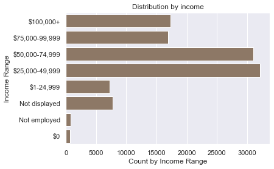

```python
# buidling the countplot
base_color = sb.color_palette()[5]
sns =  sb.countplot(data = loans, y = 'IncomeRange', order = ['$100,000+','$75,000-99,999','$50,000-74,999', '$25,000-49,999', '$1-24,999', 'Not displayed', 'Not employed', '$0'], color = base_color)
sns.set(xlabel='Count by Income Range', ylabel='Income Range')
sns.set_title("Distribution by income");
```

It seems that the people who earn between 25k and 75k comprise the most people who are having a loan

#### Next let's have a look at the ocupation of the borrowers

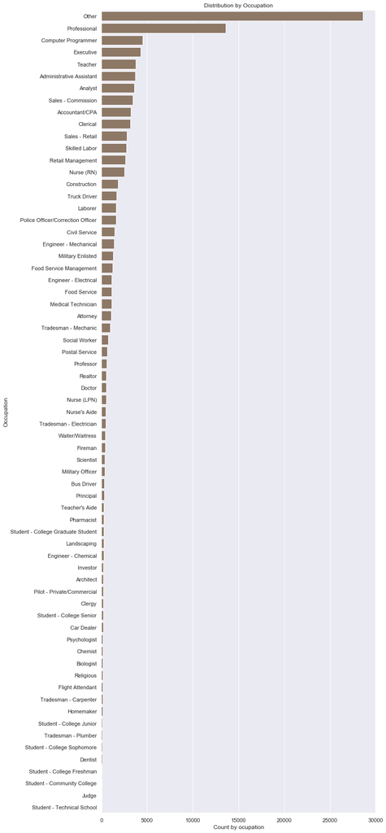

```python
#building the countplot based on the occupation
plt.figure(figsize=(10,30))
sns =  sb.countplot(data = loans, y = 'Occupation', color = base_color, order=loans['Occupation'].value_counts().index)

sns.set(xlabel='Count by ocupation', ylabel='Occupation')
sns.set_title("Distribution by Occupation");
```

The `other` category is hugely overrepresented in this sample

#### Next we'll be looking at the Employment status

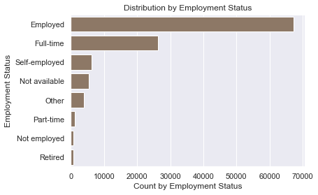

```python
# building the countplot for the employment status
sns =  sb.countplot(data = loans, y = 'EmploymentStatus',  color = base_color, order = loans.EmploymentStatus.value_counts().index)
sns.set(xlabel='Count by Employment Status', ylabel='Employment Status')
sns.set_title("Distribution by Employment Status");
```

That is interesting, most of the people are employeed

#### Next, we will look at Home Ownership status situation

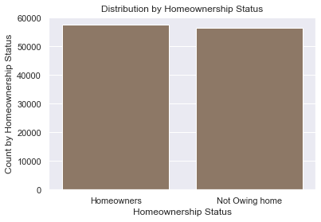

```python
# building the countplot
sns =  sb.countplot(data = loans, x = 'IsBorrowerHomeowner',  color = base_color, order = loans.IsBorrowerHomeowner.value_counts().index)
sns.set(xlabel='Homeownership Status', ylabel= 'Count by Homeownership Status')

plt.xticks(np.arange(2), ['Homeowners', 'Not Owing home'])
sns.set_title("Distribution by Homeownership Status");
```

Hm... half of the borrowers are homeowners and half are not

#### Next, last but not least, the debt to income ratio

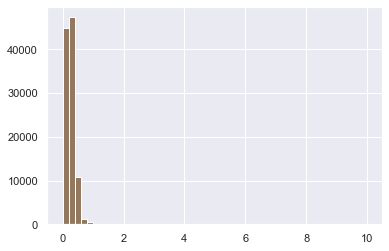

```python
# defining the edges
bin_edges = np.arange(0, loans.DebtToIncomeRatio.max(), 0.2)
# building the plot
plt.hist(loans.DebtToIncomeRatio, bins = bin_edges, color=base_color);
```

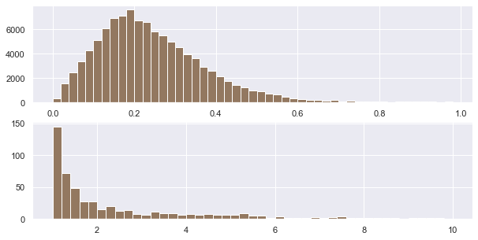

```python
# defining the figure size
plt.figure(figsize = [10, 5])
# separating the data in : 1st set
data_set1 = loans.query('DebtToIncomeRatio < 1')['DebtToIncomeRatio']
# ... and second set
data_set2 = loans.query('DebtToIncomeRatio > 1')['DebtToIncomeRatio']
# defining the position in the subplot
plt.subplot(2, 1, 1)
# defining the bin edges
bin_edges = np.arange(0, data_set1.max(), 0.02)
# plotting the first graph
plt.hist(data_set1, bins = bin_edges, color=base_color);
# defining the position for the second graph
plt.subplot(2, 1, 2)
# defining the bin edges
bin_edges = np.arange(1, data_set2.max(), 0.2)
# plotting the graph
plt.hist(data_set2, bins = bin_edges, color=base_color);
```

Now we can see more clearly how the distributions are drawn. Also the values a bit higher than 1 display an unusual pattern

### Discuss the distribution(s) of your variable(s) of interest. Were there any unusual points? Did you need to perform any transformations?

The last analysed variable, the debt to income ratio, the range of the values is so high that I had to split the grapsh into two in order to be able to visualize the data accordingly.

### Of the features you investigated, were there any unusual distributions? Did you perform any operations on the data to tidy, adjust, or change the form of the data? If so, why did you do this?

Most of the data would not fit into normal countplot graph, this is why chose to display most of the data horizontaly.

## Bivariate Exploration

#### Let's look if a loan is past due/default or current by revenue

```python
# feature engineering: building the past_due_tf on wether the LoanStatus is Past or Default
loans['past_due_tf'] = loans['LoanStatus'].str.contains('Past|Default')
```

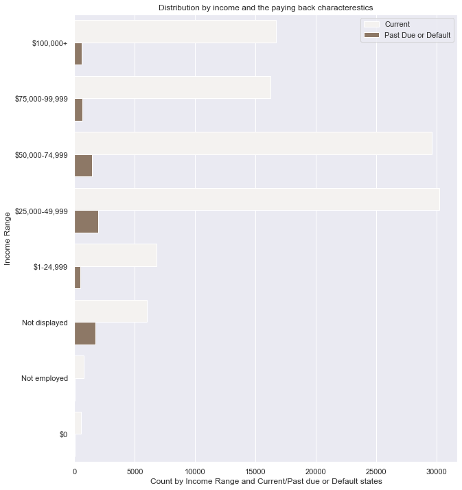

```python
# defining the size of the figure
plt.figure(figsize=(10,12))
# choosin the base color palette
base_color = sb.color_palette()[5]
# building the countplot with the hue
sns =  sb.countplot(data = loans, y = 'IncomeRange', hue = 'past_due_tf', order = ['$100,000+','$75,000-99,999','$50,000-74,999', '$25,000-49,999', '$1-24,999', 'Not displayed', 'Not employed', '$0'], color = base_color)
# defining the x and  y labels
sns.set(xlabel='Count by Income Range and Current/Past due or Default states', ylabel='Income Range')
# defining the legend
plt.legend(title='', loc='upper right', labels=['Current', 'Past Due or Default'])
# defining the title
sns.set_title("Distribution by income and the paying back characterestics");
```

### Next, we'll look at the employment status and the default/past due loans

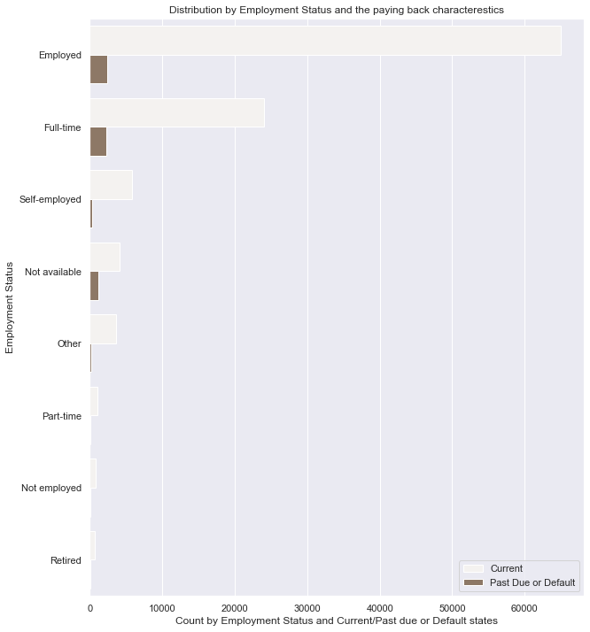

```python
# defining the figure
plt.figure(figsize=(10,12))
# building the contplot with the hue
sns =  sb.countplot(data = loans, y = 'EmploymentStatus', hue = 'past_due_tf', order = loans.EmploymentStatus.value_counts().index, color = base_color)
# setting the x and y labels
sns.set(xlabel='Count by Employment Status and Current/Past due or Default states', ylabel='Employment Status')
# plotting the legend
plt.legend(title='', loc='lower right', labels=['Current', 'Past Due or Default'])
# plotting the title
sns.set_title("Distribution by Employment Status and the paying back characterestics");
```

Self employed people seem to be more reliable when paying back the loans

#### Let's see the same characteristic based on the homeownership

[figure not shown]

```python
# building the figure
sns =  sb.countplot(data = loans, x = 'IsBorrowerHomeowner', hue = 'past_due_tf',  color = base_color, order = loans.IsBorrowerHomeowner.value_counts().index)
# setting the labels
sns.set(xlabel='Homeownership Status', ylabel= 'Count by Homeownership Status')
# building the legend
L = plt.legend()
# setting first var
L.get_texts()[0].set_text('Past Due or Default')
# setting second var
L.get_texts()[1].set_text('Current')
# moving the legend outside the plot
L.set(bbox_to_anchor=(1.05, 1))
# setting the title
sns.set_title("Distribution by Homeownership Status and paying back characteristics");
```

### Talk about some of the relationships you observed in this part of the investigation. How did the feature(s) of interest vary with other features in the dataset?

There seems to be not much interaction between the values I looked at.

### Did you observe any interesting relationships between the other features (not the main feature(s) of interest)?

Yes, the self employed seem to not default on their loans, however more statistical analyses is needed here.

## Multivariate Exploration

#### Let's have a look at the interaction between loan size, interest charged and homeownership

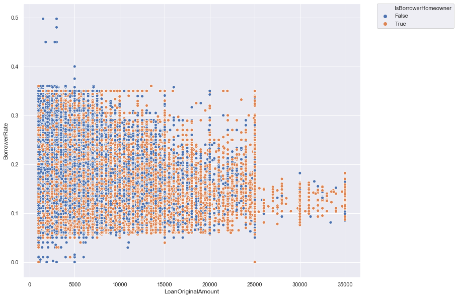

```python
# defining the size of the figure
plt.figure(figsize=(12,10))
# choosing the color palette
base_color = sb.color_palette()[4]
# building the scatterplot
sb.scatterplot(data = loans, x = 'LoanOriginalAmount', y = 'BorrowerRate', hue = 'IsBorrowerHomeowner')
# setting the title
sns.set_title("Relationship between loan size and interest charghed by homeownership")
# moving the legend outside the grapth
plt.legend(bbox_to_anchor=(1.05, 1), loc=2, borderaxespad=0);
```

There is no clear correlation but the he homeowners seem to be stacked in the lower right corner meaning lower borrower rate and higher loan ammounts

#### last but not least, the interaction between Debt to Income Ratio, Loan Amount and homeownership

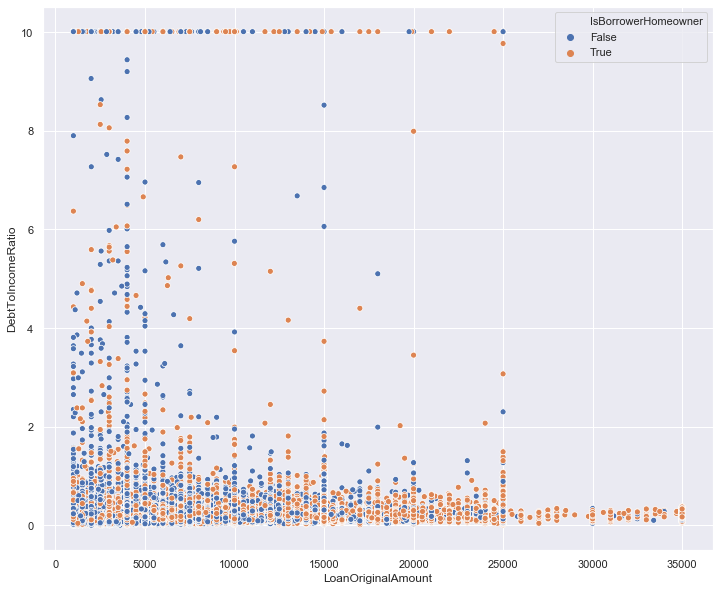

```python
# defining the size of the figure
plt.figure(figsize=(12,10))
# choosing the color palette
base_color = sb.color_palette()[4]
# building the scatterplot
sb.scatterplot(data = loans, x = 'LoanOriginalAmount', y = 'DebtToIncomeRatio', hue = 'IsBorrowerHomeowner')
# setting the title
sns.set_title("Relationship between DebtToIncomeRatio and Loan Size charghed by homeownership");
```

Again there seems that homeowners have lower debt to income ratios and therefore can afford larger loan ammounts

### Talk about some of the relationships you observed in this part of the investigation. Were there features that strengthened each other in terms of looking at your feature(s) of interest?

Although overal homeownership is distributed equally it might have an impact on the loan characteristics

### Were there any interesting or surprising interactions between features?

The surprising thing is that there might be some influence in owning a home and a bigger size of the loan